# R Notebook

```r
library(tidyverse)
library(GGally)
library(ggfortify)
library(fastDummies)
```

```r
house <- read_csv("data/housing_prices.csv")
house
```

| longitude | latitude | housing_median_age | total_rooms | total_bedrooms | population | households | median_income | median_house_value | ocean_proximity |
| --- | --- | --- | --- | --- | --- | --- | --- | --- | --- |
| -122.23 | 37.88 | 41 | 880 | 129 | 322 | 126 | 8.3252 | 452600 | NEAR BAY |
| -122.22 | 37.86 | 21 | 7099 | 1106 | 2401 | 1138 | 8.3014 | 358500 | NEAR BAY |
| -122.24 | 37.85 | 52 | 1467 | 190 | 496 | 177 | 7.2574 | 352100 | NEAR BAY |
| -122.25 | 37.85 | 52 | 1274 | 235 | 558 | 219 | 5.6431 | 341300 | NEAR BAY |
| -122.25 | 37.85 | 52 | 1627 | 280 | 565 | 259 | 3.8462 | 342200 | NEAR BAY |
| -122.25 | 37.85 | 52 | 919 | 213 | 413 | 193 | 4.0368 | 269700 | NEAR BAY |
| -122.25 | 37.84 | 52 | 2535 | 489 | 1094 | 514 | 3.6591 | 299200 | NEAR BAY |
| -122.25 | 37.84 | 52 | 3104 | 687 | 1157 | 647 | 3.1200 | 241400 | NEAR BAY |
| -122.26 | 37.84 | 42 | 2555 | 665 | 1206 | 595 | 2.0804 | 226700 | NEAR BAY |
| -122.25 | 37.84 | 52 | 3549 | 707 | 1551 | 714 | 3.6912 | 261100 | NEAR BAY |

[output cut: 990 more lines]

Notes:  
- What does one row represent? An aggregate of a district in California  
- Some variables are raw sums, some are stats, like averages  
–> do some feature engineering / variablbe transformation to get more stats that are meaningful about these houses

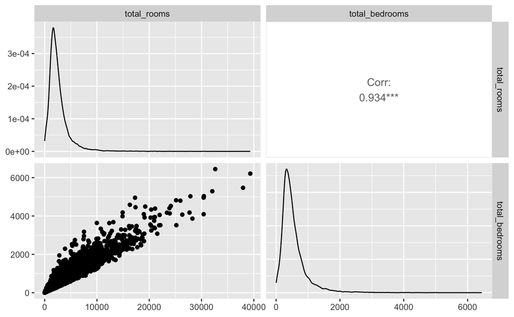

```r
house %>%
  select(total_rooms, total_bedrooms) %>%
  ggpairs()
```

We could investigate:  
- (rooms - bedrooms) = non-bedrooms  
- bedrooms / rooms = proportion of bedrooms

Feature Engineering  
- The data set we start with is the “raw material”  
- We can use those to make more meaning and aid interpretation –> “feature engineering”

```r
house <- house %>%
  mutate(bedrooms_per_house = total_bedrooms / households,
         rooms_per_house = total_rooms / households,
         people_per_house = population / households,
         bedrooms_per_person = total_bedrooms / population,
         rooms_per_person = total_rooms / population,
         bedrooms_per_room = total_bedrooms / total_rooms,
         non_bedrooms_per_house = rooms_per_house - bedrooms_per_house
         )

glimpse(house)
```

```
Rows: 19,675
Columns: 17
$ longitude              <dbl> -122.23, -122.22, -122.24, -122.25, -122.25, -122.25…
$ latitude               <dbl> 37.88, 37.86, 37.85, 37.85, 37.85, 37.85, 37.84, 37.…
$ housing_median_age     <dbl> 41, 21, 52, 52, 52, 52, 52, 52, 42, 52, 52, 52, 52, …
$ total_rooms            <dbl> 880, 7099, 1467, 1274, 1627, 919, 2535, 3104, 2555, …
$ total_bedrooms         <dbl> 129, 1106, 190, 235, 280, 213, 489, 687, 665, 707, 4…
$ population             <dbl> 322, 2401, 496, 558, 565, 413, 1094, 1157, 1206, 155…
$ households             <dbl> 126, 1138, 177, 219, 259, 193, 514, 647, 595, 714, 4…
$ median_income          <dbl> 8.3252, 8.3014, 7.2574, 5.6431, 3.8462, 4.0368, 3.65…
$ median_house_value     <dbl> 452600, 358500, 352100, 341300, 342200, 269700, 2992…
$ ocean_proximity        <chr> "NEAR BAY", "NEAR BAY", "NEAR BAY", "NEAR BAY", "NEA…
$ bedrooms_per_house     <dbl> 1.0238095, 0.9718805, 1.0734463, 1.0730594, 1.081081…
$ rooms_per_house        <dbl> 6.984127, 6.238137, 8.288136, 5.817352, 6.281853, 4.…
$ people_per_house       <dbl> 2.555556, 2.109842, 2.802260, 2.547945, 2.181467, 2.…
$ bedrooms_per_person    <dbl> 0.4006211, 0.4606414, 0.3830645, 0.4211470, 0.495575…
$ rooms_per_person       <dbl> 2.732919, 2.956685, 2.957661, 2.283154, 2.879646, 2.…
$ bedrooms_per_room      <dbl> 0.1465909, 0.1557966, 0.1295160, 0.1844584, 0.172095…
$ non_bedrooms_per_house <dbl> 5.960317, 5.266257, 7.214689, 4.744292, 5.200772, 3.…
```

```r
skimr::skim(house) %>% view()
```

- Extra idea: start using long & lats to make more meaning –> joining to external city coordinate data, creating labels, flags, or things like distance from city or from the coast.

Let’s explore the relationships between the variables - what looks like it influences price?

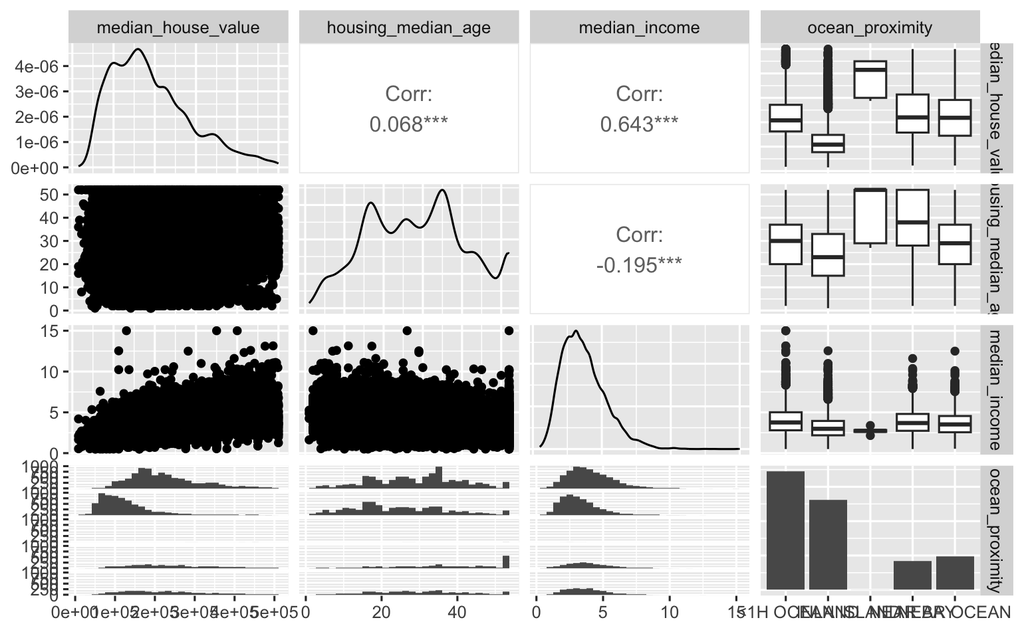

```r
ggpairs1 <- house %>%
  select(median_house_value,
         housing_median_age,
         median_income,
         ocean_proximity) %>%
  ggpairs()

ggpairs1
```

- house age and house value = weakly positively correlated
- income and house value = strongly positively correlated
- ocean proximity and house value = 3 categories behave similarly –> what do we do with these? group them?
- plot 1 shows the distribution of house values across the various districts = skewed

```r
house %>%
  count(ocean_proximity)
```

| ocean_proximity | n |
| --- | --- |
| <1H OCEAN | 8604 |
| INLAND | 6524 |
| ISLAND | 5 |
| NEAR BAY | 2096 |
| NEAR OCEAN | 2446 |

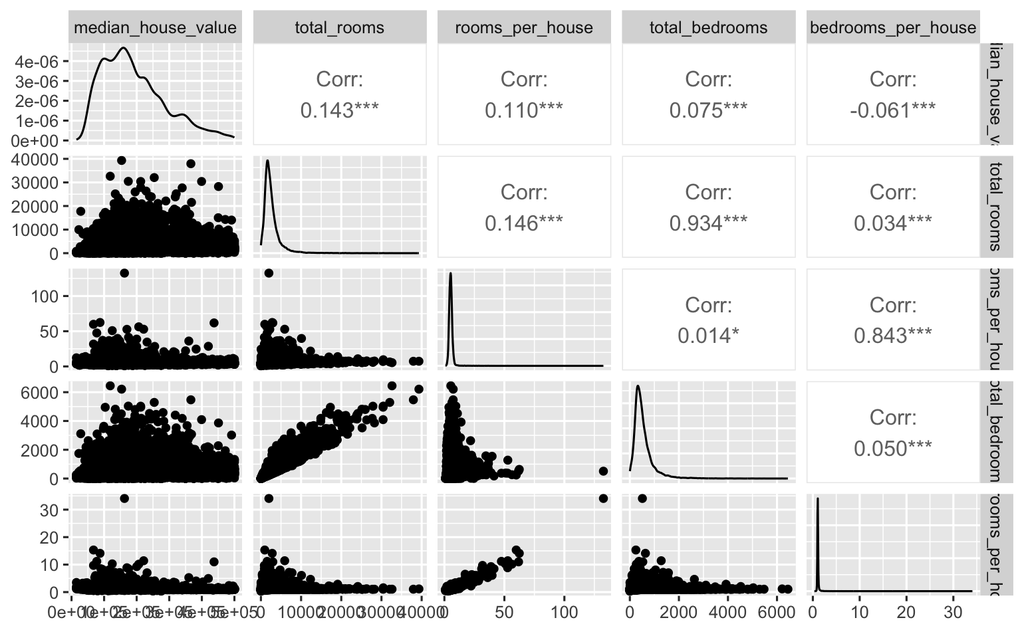

```r
ggpairs2 <- house %>%
  select(median_house_value,
         total_rooms,
         rooms_per_house,
         total_bedrooms,
         bedrooms_per_house) %>%
  ggpairs()

ggpairs2
```

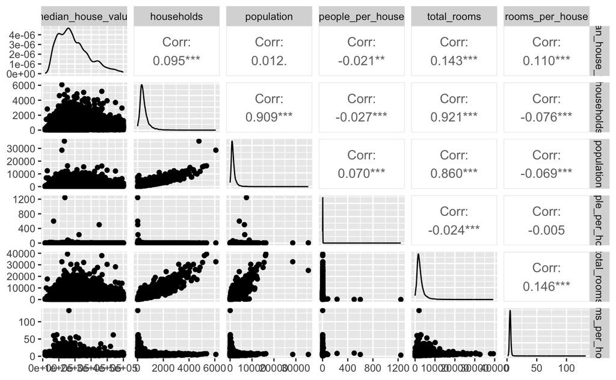

```r
ggpairs3 <- house %>%
  select(median_house_value,
         households,
         population,
         people_per_house,
         total_rooms,
         rooms_per_house) %>%
  ggpairs()

ggpairs3
```

- households –> proxy –> urban/city

```r
house %>%
  select_if(is.numeric) %>%
  skimr::skim()
```

```
── Data Summary ────────────────────────
                           Values
Name                       Piped data
Number of rows             19675
Number of columns          16
_______________________
Column type frequency:
  numeric                  16
________________________
Group variables            None
```

|  | skim_variable | n_missing | complete_rate | mean | sd | p0 | p25 | p50 | p75 | p100 | hist |
| --- | --- | --- | --- | --- | --- | --- | --- | --- | --- | --- | --- |
| 1 | longitude | 0 | 1.0000000 | -1.195632e+02 | 2.006108e+00 | -1.243500e+02 | -1.217600e+02 | -1.185000e+02 | -1.179900e+02 | -114.31000 | ▂▆▃▇▁ |
| 2 | latitude | 0 | 1.0000000 | 3.565178e+01 | 2.149802e+00 | 3.254000e+01 | 3.393000e+01 | 3.427000e+01 | 3.773000e+01 | 41.95000 | ▇▁▅▂▁ |
| 3 | housing_median_age | 0 | 1.0000000 | 2.838628e+01 | 1.250911e+01 | 1.000000e+00 | 1.800000e+01 | 2.800000e+01 | 3.700000e+01 | 52.00000 | ▃▇▇▇▅ |
| 4 | total_rooms | 0 | 1.0000000 | 2.619764e+03 | 2.181348e+03 | 2.000000e+00 | 1.438000e+03 | 2.111000e+03 | 3.120000e+03 | 39320.00000 | ▇▁▁▁▁ |
| 5 | total_bedrooms | 200 | 0.9898348 | 5.396458e+02 | 4.224132e+02 | 2.000000e+00 | 2.970000e+02 | 4.360000e+02 | 6.480000e+02 | 6445.00000 | ▇▁▁▁▁ |
| 6 | population | 0 | 1.0000000 | 1.440812e+03 | 1.143649e+03 | 3.000000e+00 | 7.960000e+02 | 1.179000e+03 | 1.746000e+03 | 35682.00000 | ▇▁▁▁▁ |
| 7 | households | 0 | 1.0000000 | 5.011860e+02 | 3.832646e+02 | 2.000000e+00 | 2.820000e+02 | 4.110000e+02 | 6.060000e+02 | 6082.00000 | ▇▁▁▁▁ |
| 8 | median_income | 0 | 1.0000000 | 3.676717e+00 | 1.570272e+00 | 4.999000e-01 | 2.526800e+00 | 3.450000e+00 | 4.582600e+00 | 15.00010 | ▇▇▁▁▁ |
| 9 | median_house_value | 0 | 1.0000000 | 1.924779e+05 | 9.771151e+04 | 1.499900e+04 | 1.166000e+05 | 1.738000e+05 | 2.482000e+05 | 500000.00000 | ▅▇▅▂▁ |
| 10 | bedrooms_per_house | 200 | 0.9898348 | 1.097017e+00 | 4.539334e-01 | 3.333333e-01 | 1.005888e+00 | 1.048780e+00 | 1.099462e+00 | 34.06667 | ▇▁▁▁▁ |

[output cut: 6 more lines]

Might want to do some transformation of highly positively skewed numeric –> e.g. take logs

```r
mod1 <- lm(median_house_value ~ median_income,
           data = house)

summary(mod1)
```

```
Call:
lm(formula = median_house_value ~ median_income, data = house)

Residuals:
    Min      1Q  Median      3Q     Max
-513966  -51564  -13979   36549  403935

Coefficients:
              Estimate Std. Error t value Pr(>|t|)
(Intercept)    45457.0     1359.0   33.45   <2e-16 ***
median_income  39987.0      339.9  117.64   <2e-16 ***
---
Signif. codes:  0 ‘***’ 0.001 ‘**’ 0.01 ‘*’ 0.05 ‘.’ 0.1 ‘ ’ 1

Residual standard error: 74870 on 19673 degrees of freedom
Multiple R-squared:  0.4129,    Adjusted R-squared:  0.4129
F-statistic: 1.384e+04 on 1 and 19673 DF,  p-value: < 2.2e-16
```

- stars = significance
- is the estimate equals to zero or significantly different? –> price = (constant = a = intercept = 45457) + (increment = b = 39987) x income
- r^2 = explains 41.3% of variation (it goeas from 0 to 1)

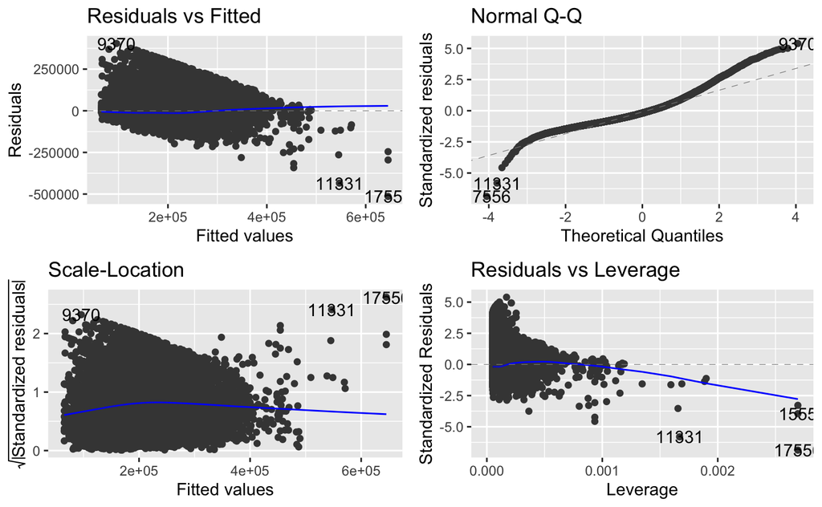

```r
autoplot(mod1)
```

- 1. residual = how wrong we were, how far from our model –> fitted_value = our estimate of the price = what we guessed; residual = the amount we were wrong by; is hovering around zero in a random way
- 2. where the points would be if they were normal –> we want our residual to be normal; doesn’t look like a straight line, indication of long tails
- 3. is the amount we are wrong by consistent? is there pattern? 2 standard deviations wrong –> a pattern of how wrong we were = yes –> where the points are more clustered we are more wrong (?)

```r
mod2 <- lm(median_house_value ~ ocean_proximity,
           data = house)

summary(mod2)
```

```
Call:
lm(formula = median_house_value ~ ocean_proximity, data = house)

Residuals:
    Min      1Q  Median      3Q     Max
-214426  -57783  -15113   41347  376747

Coefficients:
                           Estimate Std. Error t value Pr(>|t|)
(Intercept)                224013.2      911.7 245.717  < 2e-16 ***
ocean_proximityINLAND     -100760.6     1388.3 -72.580  < 2e-16 ***
ocean_proximityISLAND      156426.8    37829.4   4.135 3.56e-05 ***
ocean_proximityNEAR BAY     12912.4     2059.8   6.269 3.72e-10 ***
ocean_proximityNEAR OCEAN    3703.6     1937.7   1.911    0.056 .
---
Signif. codes:  0 ‘***’ 0.001 ‘**’ 0.01 ‘*’ 0.05 ‘.’ 0.1 ‘ ’ 1

Residual standard error: 84560 on 19670 degrees of freedom
Multiple R-squared:  0.2511,    Adjusted R-squared:  0.251
F-statistic:  1649 on 4 and 19670 DF,  p-value: < 2.2e-16
```

```r
mod3 <- lm(median_house_value ~ ocean_proximity + median_income,
           data = house)

summary(mod3)
```

```
Call:
lm(formula = median_house_value ~ ocean_proximity + median_income,
    data = house)

Residuals:
    Min      1Q  Median      3Q     Max
-479055  -41086  -11143   27912  376647

Coefficients:
                          Estimate Std. Error t value Pr(>|t|)
(Intercept)                83581.2     1407.7  59.373  < 2e-16 ***
ocean_proximityINLAND     -72313.7     1100.7 -65.695  < 2e-16 ***
ocean_proximityISLAND     200480.2    29232.9   6.858 7.19e-12 ***
ocean_proximityNEAR BAY    16629.7     1591.9  10.446  < 2e-16 ***
ocean_proximityNEAR OCEAN  15552.9     1500.8  10.363  < 2e-16 ***
median_income              35118.0      304.8 115.223  < 2e-16 ***
---
Signif. codes:  0 ‘***’ 0.001 ‘**’ 0.01 ‘*’ 0.05 ‘.’ 0.1 ‘ ’ 1

Residual standard error: 65340 on 19669 degrees of freedom
Multiple R-squared:  0.5529,    Adjusted R-squared:  0.5528
F-statistic:  4865 on 5 and 19669 DF,  p-value: < 2.2e-16
```

```r
library(raster)
library(leaflet)
raster <- rasterFromXYZ(house %>%
  dplyr::select(longitude, latitude, median_house_value), crs = "+proj=longlat +ellps=WGS84 +datum=WGS84 +no_defs")

pal <- colorNumeric(c("blue", "red", "yellow"), values(raster),
  na.color = "transparent")

leaflet() %>%
  addTiles() %>%
  addRasterImage(raster, colors = pal, opacity = 0.7) %>%
  addLegend(pal = pal, values = values(raster),
    title = "Median House Value")
```

[interactive chart not shown]

Log transformations

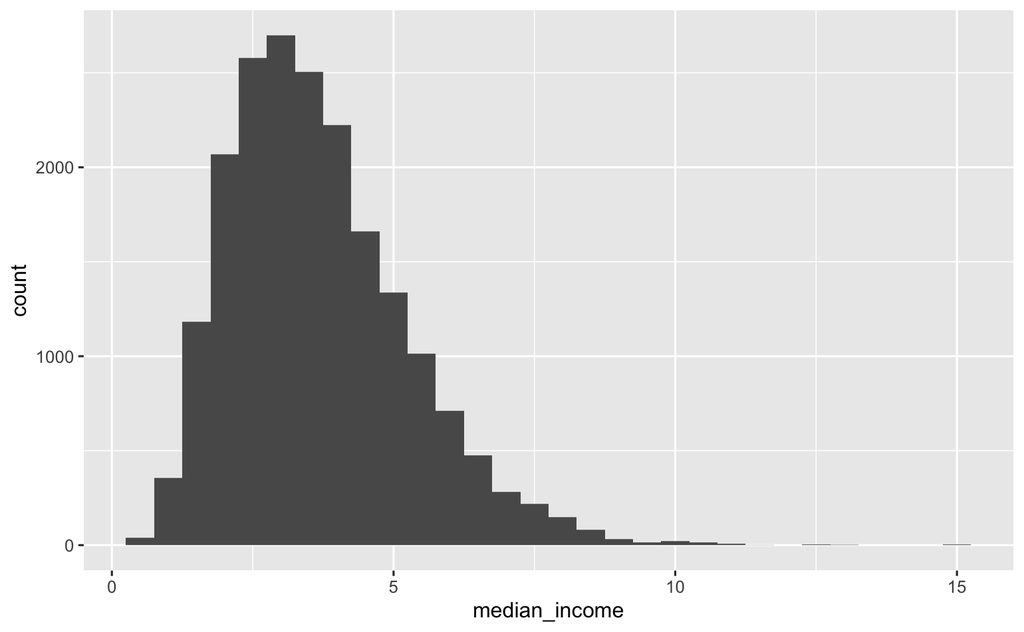

```r
ggplot(house, aes(x = median_income)) +
  geom_histogram()
```

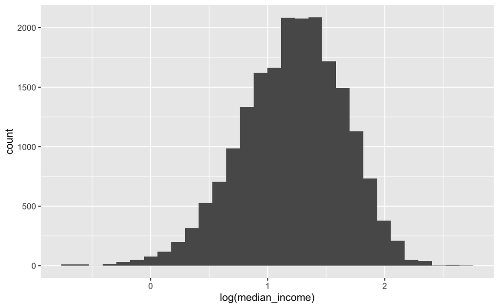

```r
ggplot(house, aes(x = log(median_income))) +
  geom_histogram()
```

lognormal centered around the mean

```r
mod4 <- lm(median_house_value ~ ocean_proximity +
             log(median_income) + median_income,
           data = house)

summary(mod4)
```

```
Call:
lm(formula = median_house_value ~ ocean_proximity + log(median_income) +
    median_income, data = house)

Residuals:
    Min      1Q  Median      3Q     Max
-513207  -40894  -11507   27736  374026

Coefficients:
                          Estimate Std. Error t value Pr(>|t|)
(Intercept)                  88652       1632  54.318  < 2e-16 ***
ocean_proximityINLAND       -72633       1101 -65.973  < 2e-16 ***
ocean_proximityISLAND       201255      29206   6.891 5.71e-12 ***
ocean_proximityNEAR BAY      16572       1590  10.419  < 2e-16 ***
ocean_proximityNEAR OCEAN    15668       1500  10.449  < 2e-16 ***
log(median_income)          -22173       3621  -6.123 9.34e-10 ***
median_income                41060       1017  40.373  < 2e-16 ***
---
Signif. codes:  0 ‘***’ 0.001 ‘**’ 0.01 ‘*’ 0.05 ‘.’ 0.1 ‘ ’ 1

Residual standard error: 65280 on 19668 degrees of freedom
Multiple R-squared:  0.5538,    Adjusted R-squared:  0.5536
F-statistic:  4068 on 6 and 19668 DF,  p-value: < 2.2e-16
```

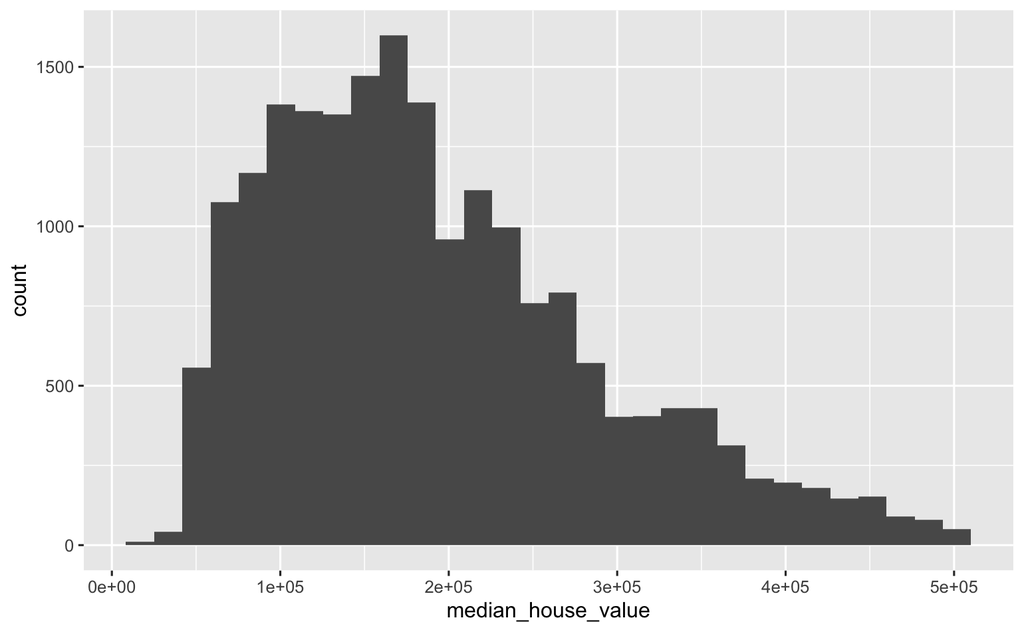

```r
ggplot(house, aes(x = median_house_value)) +
  geom_histogram()
```

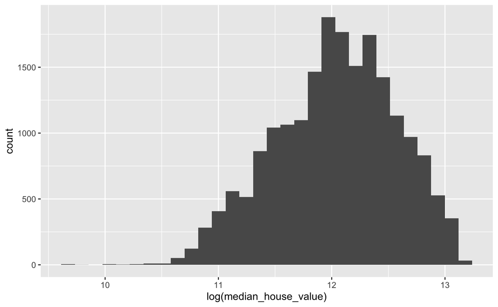

```r
ggplot(house, aes(x = log(median_house_value))) +
  geom_histogram()
```

```r
mod5 <- lm(log(median_house_value) ~ ocean_proximity +
             log(median_income) + median_income,
           data = house)

summary(mod5)
```

```
Call:
lm(formula = log(median_house_value) ~ ocean_proximity + log(median_income) +
    median_income, data = house)

Residuals:
     Min       1Q   Median       3Q      Max
-2.20682 -0.21851 -0.02106  0.19876  1.74193

Coefficients:
                           Estimate Std. Error  t value Pr(>|t|)
(Intercept)               11.429630   0.008338 1370.820  < 2e-16 ***
ocean_proximityINLAND     -0.486425   0.005624  -86.484  < 2e-16 ***
ocean_proximityISLAND      0.804212   0.149205    5.390 7.13e-08 ***
ocean_proximityNEAR BAY    0.047981   0.008125    5.905 3.58e-09 ***
ocean_proximityNEAR OCEAN  0.042832   0.007661    5.591 2.28e-08 ***
log(median_income)         0.338366   0.018499   18.291  < 2e-16 ***
median_income              0.094038   0.005196   18.100  < 2e-16 ***
---
Signif. codes:  0 ‘***’ 0.001 ‘**’ 0.01 ‘*’ 0.05 ‘.’ 0.1 ‘ ’ 1

Residual standard error: 0.3335 on 19668 degrees of freedom
Multiple R-squared:  0.6091,    Adjusted R-squared:  0.6089
F-statistic:  5107 on 6 and 19668 DF,  p-value: < 2.2e-16
```

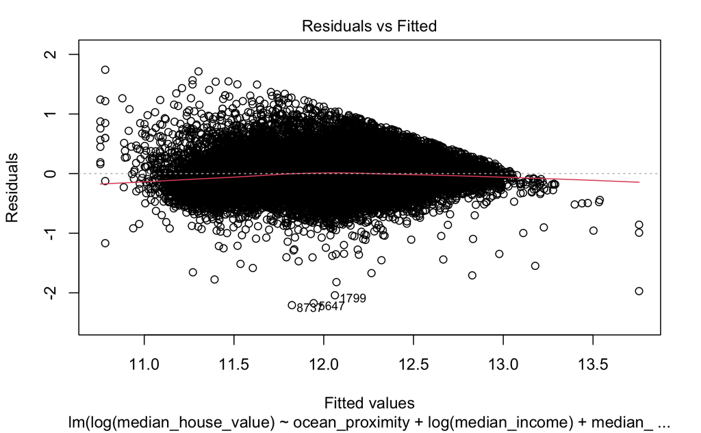

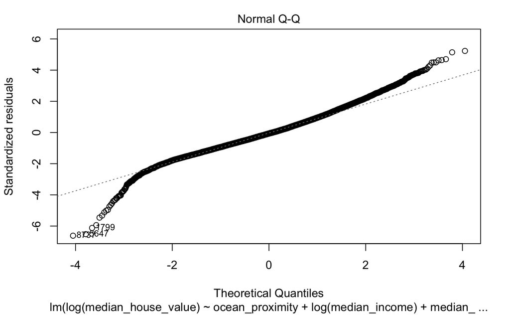

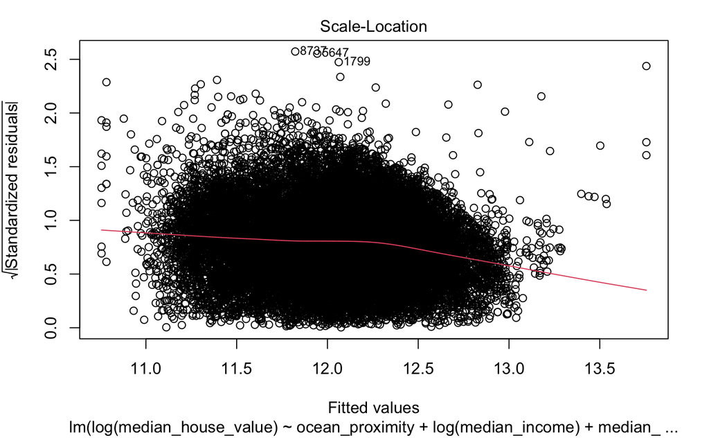

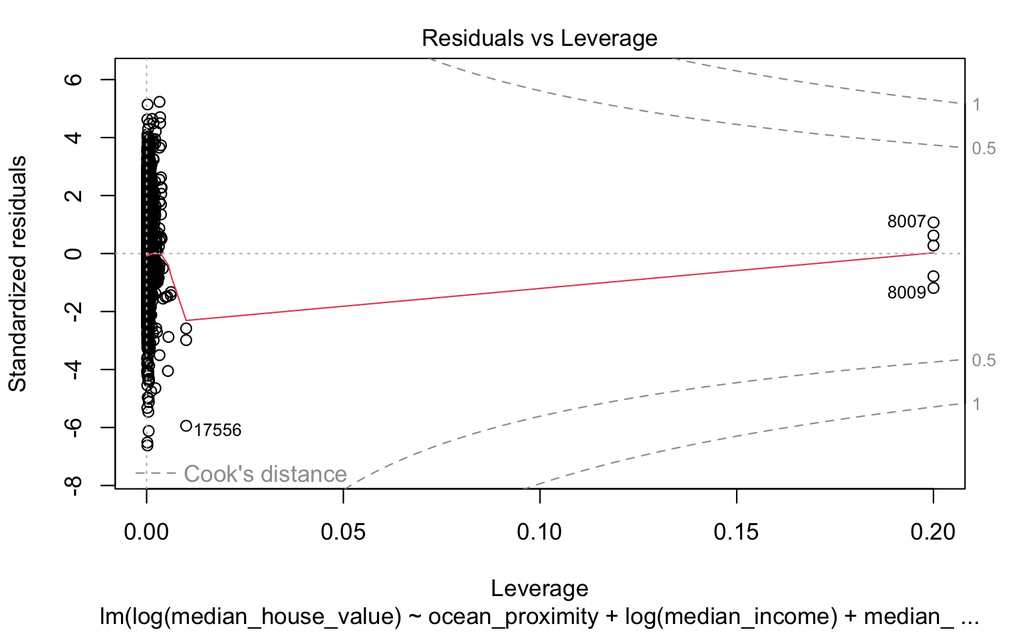

```r
plot(mod5)
```